# Chess Elo Prediction — v3

**Multi-task neural network: BiLSTM with attention + static features + optional sequence autoencoder.**

## 0 — Imports

## 1 — Config

Everything in one place. Read the comments — they explain what to change for laptop vs GPU runs.

```
Device : cpu  |  AMP : False  |  CPU threads : 14
Sequential=False  AE=True  DistTarget=True
```

## 2 — Data Loading

```
Loaded 200,000 games in 8.4s
Removed 66,359 games by termination
Kept 108,554 games after TC filter (removed 24,632)
Elo — White 778–2812,  Black 771–2918
```

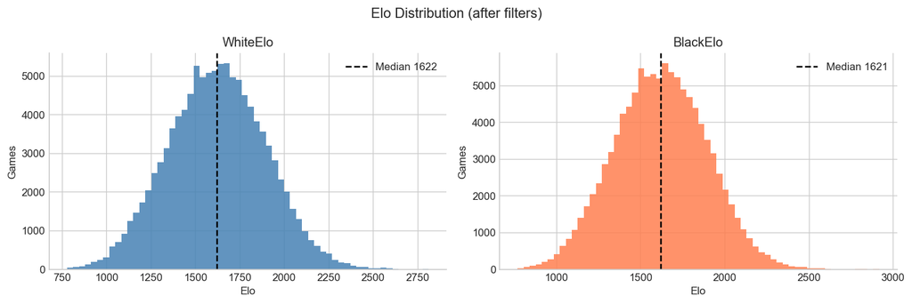

## 3 — Feature Extraction *(cached)*

Board and clock features are saved to `cache/` so they only recompute when you change the data.

```
Board features loaded from cache (35 cols)
Clock features loaded from cache (10 cols)
Full feature matrix: (108554, 69)
```

## 4 — Move Tokenisation

```
Dropped 1,410 short games
Vocab size : 7,258   Games ready: 107,144
```

## 5 — Soft Distribution Targets *(Ouzounis-style)*

Rather than regressing to a single number, the model learns to output a probability distribution over 40 Elo buckets (each 100 points wide). The ground truth for each player is a Gaussian centred on their actual Elo with σ=200, then discretised into those buckets. This captures the fact that a player's single-game performance is noisy around their true rating.

```
Distribution for 1600: peak bin=1550,  recovered Elo=1600
```

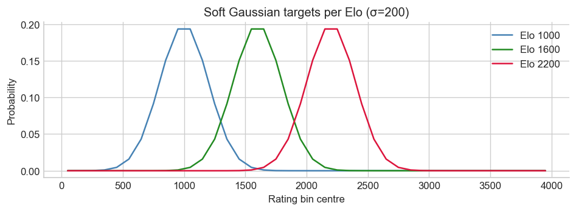

## 6 — Feature Selection, Split & Scaling

```
Static columns: 45
  [on] game_structure      (3 cols)
  [on] checks              (4 cols)
  [on] captures            (5 cols)
  [on] castling            (2 cols)
  [on] style               (9 cols)
  [on] engine_quality      (10 cols)
  [on] clock               (10 cols)
  [on] tc_meta             (2 cols)
Split — train:85,715  val:10,714  test:10,715
Scaling done (fit on train only)
```

## 7 — Sequence Autoencoder *(optional but recommended on CPU)*

The LSTM adds signal but is slow on CPU: a 200k-game run with `USE_SEQUENTIAL=True` takes hours. The autoencoder is the fix. We train it **once**, then use its **encoder half** to compress each game's move sequence into a `AE_LATENT_DIM`-dimensional vector and cache those vectors. The main model then just reads those cached vectors as extra static features — no recurrence at all during the main training loop.

**Install requirement:** `pip install torch` (already required). No extra package needed — the AE is a vanilla LSTM autoencoder built with PyTorch.

Set `USE_AE = True` in the Config cell to use this cell

```
Training sequence autoencoder...
  AE epoch 1/2  loss=7.5525
  AE epoch 2/2  loss=6.1349
AE embeddings saved: (107144, 32)
AE embeddings ready — 32 dims per game
```

## 8 — Dataset & DataLoaders

```
Building datasets...
  Built in 27.7s   total_static_dim=77
Batches/epoch: 1,340
```

## 9 — Model

Output head: when `USE_DIST_TARGET=True` the model predicts a 40-bin softmax distribution over rating ranges. Point estimate = weighted mean of that distribution. When False, direct Huber regression.

```
Trainable parameters: 1,166,257
```

## 10 — Training

```
Epoch  1/15  train 1.5143  val 1.2107  MAE W:226 B:223  lr 2.97e-04  14.6s
Epoch  2/15  train 1.1353  val 1.1571  MAE W:223 B:221  lr 2.88e-04  14.2s
Epoch  3/15  train 1.0411  val 1.0983  MAE W:214 B:212  lr 2.73e-04  17.2s
Epoch  4/15  train 0.9968  val 1.0589  MAE W:210 B:208  lr 2.53e-04  15.3s
Epoch  5/15  train 0.9658  val 1.0097  MAE W:202 B:202  lr 2.29e-04  16.1s
Epoch  6/15  train 0.9430  val 1.0761  MAE W:212 B:210  lr 2.02e-04  15.8s
Epoch  7/15  train 0.9274  val 1.0595  MAE W:208 B:206  lr 1.72e-04  13.7s
Epoch  8/15  train 0.9084  val 1.0544  MAE W:208 B:205  lr 1.43e-04  15.9s
Epoch  9/15  train 0.8948  val 1.0002  MAE W:202 B:200  lr 1.13e-04  14.8s
Early stopping at epoch 14
```

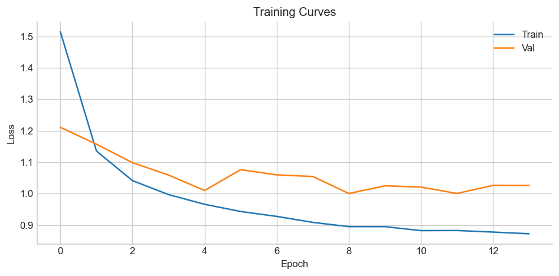

## 11 — Evaluation

```
Loaded: chess_elo_v3_2e+05.pth
MAE    — White: 201.4  Black: 201.0  Combined: 201.2
Median — White: 167.5  Black: 166.7
Within 100 Elo: 32.0%
Within 200 Elo: 57.8%
Within 300 Elo: 76.8%
```

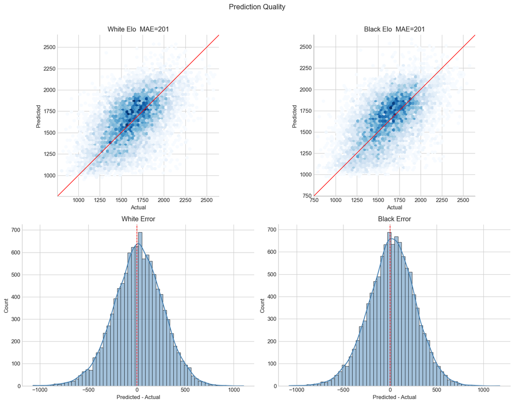

```
MAE by bracket:
----------------------------------------
           (0, 1000]  MAE=  305  n=159
        (1000, 1200]  MAE=  222  n=1,106
        (1200, 1400]  MAE=  207  n=3,260
        (1400, 1600]  MAE=  202  n=5,497
        (1600, 1800]  MAE=  183  n=5,879
        (1800, 2000]  MAE=  188  n=3,796
        (2000, 2200]  MAE=  244  n=1,370
        (2200, 2500]  MAE=  302  n=347
        (2500, 4000]  MAE=  426  n=16
```

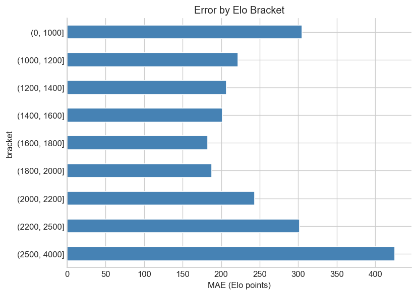

## 12 — Distribution Output Visualisation *(Ouzounis-inspired)*

```
Distribution animation requires USE_DIST_TARGET=True and USE_SEQUENTIAL=True.
With the current config we just show the final distribution for a sample game.
```

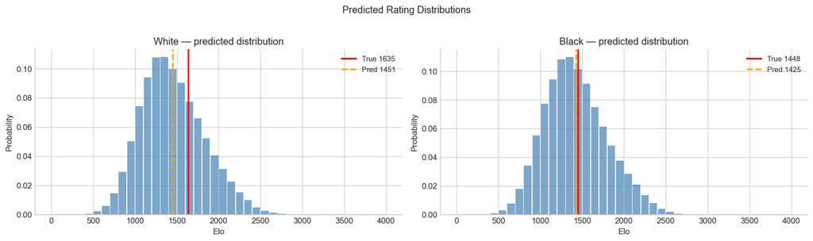

## 13 — Attention Heatmap

```
Attention heatmap requires USE_SEQUENTIAL=True.
```

## 14 — Latent Space Clustering

```
Running t-SNE on 3000 vectors...
```

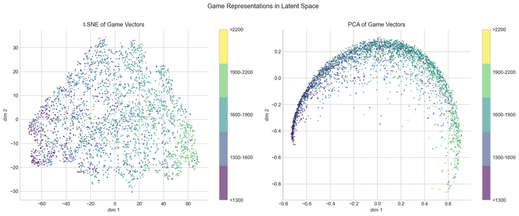

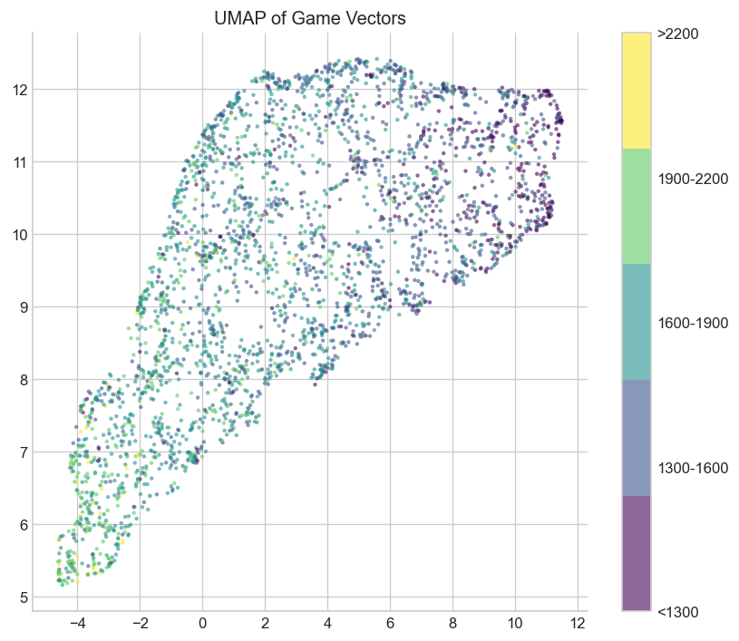

## 15 — Feature Importance & Ablation

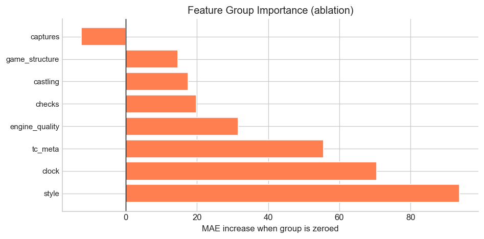

```
  style               Δ=+93.8
  clock               Δ=+70.5
  tc_meta             Δ=+55.6
  engine_quality      Δ=+31.6
  checks              Δ=+19.8
  castling            Δ=+17.6
  game_structure      Δ=+14.7
  captures            Δ=-12.5
```

## 16 — Progressive Elo Estimation

```
Progressive estimation requires USE_SEQUENTIAL=True.
```

## 17 — Opening Analysis (ECO codes)

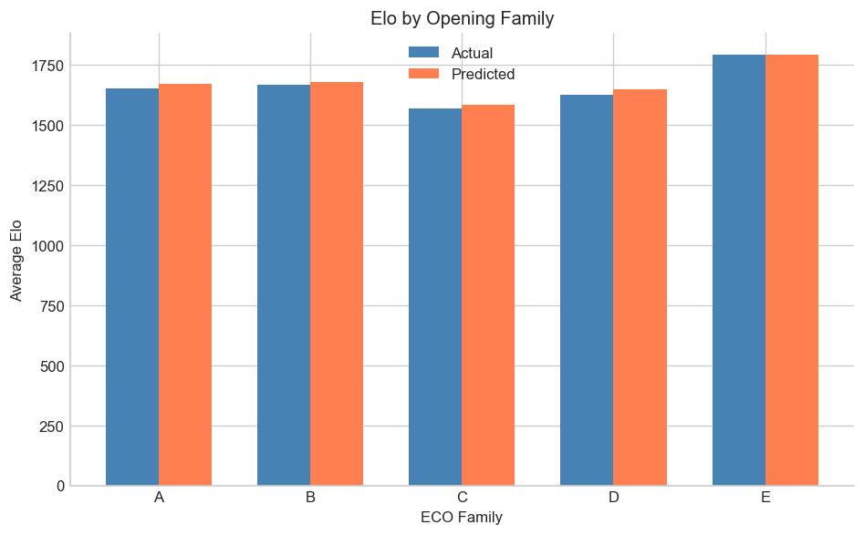

```
Top 5 highest-Elo ECO codes (min 10 games):
    A56  avg Elo: 1946  (n=11)
    A15  avg Elo: 1886  (n=30)
    D43  avg Elo: 1879  (n=14)
    B13  avg Elo: 1868  (n=40)
    C54  avg Elo: 1868  (n=13)

Bottom 5 lowest-Elo ECO codes (min 10 games):
    C20  avg Elo: 1443  (n=339)
    C40  avg Elo: 1462  (n=208)
    C27  avg Elo: 1467  (n=21)
    C43  avg Elo: 1469  (n=12)
    C57  avg Elo: 1487  (n=53)
```

## 18 — Anomaly Detection

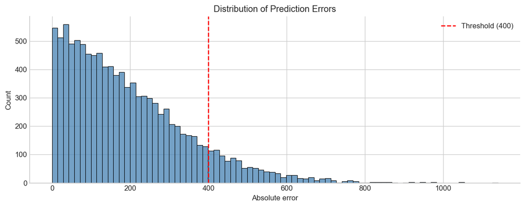

```
Flagged 1097 games > 400 Elo  (10.2%)

Top 15 OVERPERFORMERS
   Predicted      Actual      Diff
  --------------------------------
        2450        1310     +1140
        1896         944      +952
        2070        1134      +935
        2183        1325      +858
        1960        1117      +843
        2009        1168      +841
        2144        1310      +835
        1879        1068      +811
        2279        1498      +781
        1705         925      +780
```

[output cut: 24 more lines]

## 19 — Single-Game Inference *(paste any PGN)*

Paste a PGN string into `EXAMPLE_PGN` and run the cell. The model will output predicted White and Black Elos along with the full probability distribution. Works without clocks — clock features just fill with NaN.

Copy a PGN from Lichess or chess.com (the 'Share' button), paste it below.

```
=============================================
  White Elo   predicted:  1758   actual: 1546
  Black Elo   predicted:  1745   actual: 1534
=============================================
```

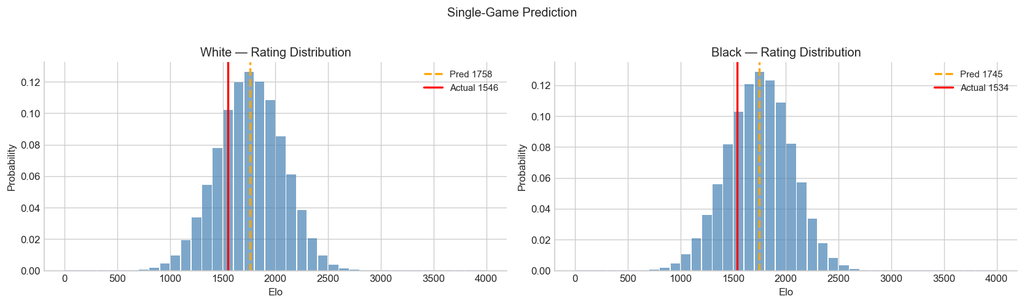

## 20 — Export

```
Exported: c:\CodeBases\AppML_FinalProject\root\workspace\elias_sandbox\output_files\chess_elo_v3_2e+05_20260603_190811.html
```